# The Quality of Wines and its Characteristics by Nicholas Huh

This report explores a dataset containg acid and ingredients, % of alcohol, and the quality of wine with 1599 rows.

# Univariate Plots Section

```
##  [1] "fixed.acidity"        "volatile.acidity"     "citric.acid"
##  [4] "residual.sugar"       "chlorides"            "free.sulfur.dioxide"
##  [7] "total.sulfur.dioxide" "density"              "pH"
## [10] "sulphates"            "alcohol"              "quality"
```

```
## 'data.frame':    1599 obs. of  12 variables:
##  $ fixed.acidity       : num  7.4 7.8 7.8 11.2 7.4 7.4 7.9 7.3 7.8 7.5 ...
##  $ volatile.acidity    : num  0.7 0.88 0.76 0.28 0.7 0.66 0.6 0.65 0.58 0.5 ...
##  $ citric.acid         : num  0 0 0.04 0.56 0 0 0.06 0 0.02 0.36 ...
##  $ residual.sugar      : num  1.9 2.6 2.3 1.9 1.9 1.8 1.6 1.2 2 6.1 ...
##  $ chlorides           : num  0.076 0.098 0.092 0.075 0.076 0.075 0.069 0.065 0.073 0.071 ...
##  $ free.sulfur.dioxide : num  11 25 15 17 11 13 15 15 9 17 ...
##  $ total.sulfur.dioxide: num  34 67 54 60 34 40 59 21 18 102 ...
##  $ density             : num  0.998 0.997 0.997 0.998 0.998 ...
##  $ pH                  : num  3.51 3.2 3.26 3.16 3.51 3.51 3.3 3.39 3.36 3.35 ...
##  $ sulphates           : num  0.56 0.68 0.65 0.58 0.56 0.56 0.46 0.47 0.57 0.8 ...
##  $ alcohol             : num  9.4 9.8 9.8 9.8 9.4 9.4 9.4 10 9.5 10.5 ...
##  $ quality             : int  5 5 5 6 5 5 5 7 7 5 ...
```

```
##  fixed.acidity   volatile.acidity  citric.acid    residual.sugar
##  Min.   : 4.60   Min.   :0.1200   Min.   :0.000   Min.   : 0.900
##  1st Qu.: 7.10   1st Qu.:0.3900   1st Qu.:0.090   1st Qu.: 1.900
##  Median : 7.90   Median :0.5200   Median :0.260   Median : 2.200
##  Mean   : 8.32   Mean   :0.5278   Mean   :0.271   Mean   : 2.539
##  3rd Qu.: 9.20   3rd Qu.:0.6400   3rd Qu.:0.420   3rd Qu.: 2.600
##  Max.   :15.90   Max.   :1.5800   Max.   :1.000   Max.   :15.500
##    chlorides       free.sulfur.dioxide total.sulfur.dioxide
##  Min.   :0.01200   Min.   : 1.00       Min.   :  6.00
##  1st Qu.:0.07000   1st Qu.: 7.00       1st Qu.: 22.00
##  Median :0.07900   Median :14.00       Median : 38.00
##  Mean   :0.08747   Mean   :15.87       Mean   : 46.47
##  3rd Qu.:0.09000   3rd Qu.:21.00       3rd Qu.: 62.00
##  Max.   :0.61100   Max.   :72.00       Max.   :289.00
##     density             pH          sulphates         alcohol
##  Min.   :0.9901   Min.   :2.740   Min.   :0.3300   Min.   : 8.40
##  1st Qu.:0.9956   1st Qu.:3.210   1st Qu.:0.5500   1st Qu.: 9.50
##  Median :0.9968   Median :3.310   Median :0.6200   Median :10.20
##  Mean   :0.9967   Mean   :3.311   Mean   :0.6581   Mean   :10.42
##  3rd Qu.:0.9978   3rd Qu.:3.400   3rd Qu.:0.7300   3rd Qu.:11.10
##  Max.   :1.0037   Max.   :4.010   Max.   :2.0000   Max.   :14.90
##     quality
##  Min.   :3.000
##  1st Qu.:5.000
##  Median :6.000
##  Mean   :5.636
##  3rd Qu.:6.000
##  Max.   :8.000
```

```
## [1] 1599   12
```

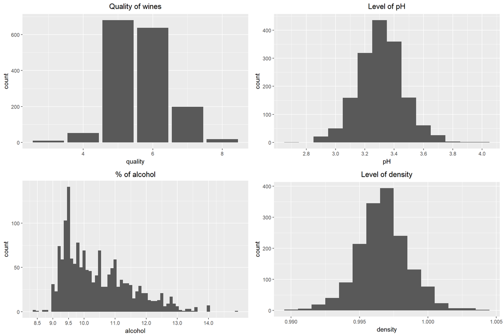

```
##    Min. 1st Qu.  Median    Mean 3rd Qu.    Max.
##   2.740   3.210   3.310   3.311   3.400   4.010
```

```
##    Min. 1st Qu.  Median    Mean 3rd Qu.    Max.
##    8.40    9.50   10.20   10.42   11.10   14.90
```

```
##    Min. 1st Qu.  Median    Mean 3rd Qu.    Max.
##   3.000   5.000   6.000   5.636   6.000   8.000
```

I can see most of wines have 5-6 quality in the dataset. Also I can see that the lowest quality is 3, highest quality is 8, median is 6, mean is 5.636 Likewise above, I can see pH sits in between 3.0 and 3.6 with lowest pH is 2.74, highest pH is 4.010, mean is 3.311, median is 3.310. Most of wines have 9.0-12.0 % of alcohol with lowest of 8.40, highest of 14.90, mean of 10.42, and median of 10.20. I am not sure how density can relate to the quality of wines, but most wines sit on between 0.995 and 1.000. Next I will see all the kinds of acid.

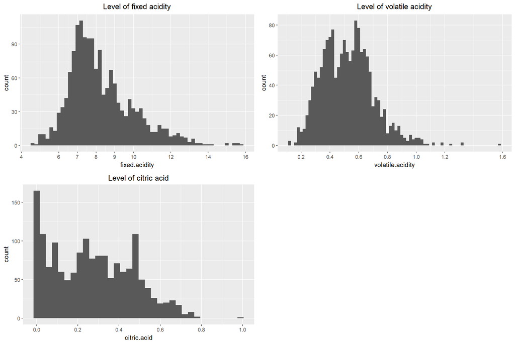

I can see most of wines have 6-10 g/dm^3 of fixed acidity and 0.2-0.8 g/dm^3 of volatile acidity. Citric acid looks a little bit different as there are a lot of wines that have no citric acid at all. Including that, most wines have 0.0-0.6 g/dm^3 of citric acid.

The following plots of each ingredient, however, need transformation for better understanding.

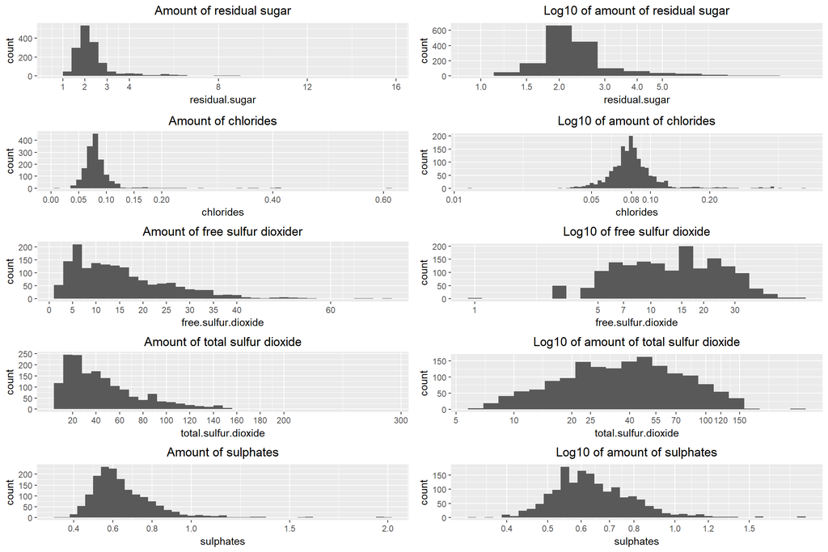

# Univariate Analysis

### What is the structure of your dataset?

There are 1,599 red wines with 11 variables (3 kinds of acid, 5 of ingredients, density, pH, % of alcohol, and quality).

Other observations:  
* Most wines are of 5 or 6 quality.  
* The median % of alcohol is 10.20.  
* Most wines sit on the pH of 3.0-3.5.  
* All ingredients shows positively skewed graph.  
* None of variable has uniform distribution.

### What is/are the main feature(s) of interest in your dataset?

The most important feature in the dataset is the quality of wine. I’d like to define what factors affect the quality of wine, the most and the least.

### What other features in the dataset do you think will help support your investigation into your feature(s) of interest?

All the variables possibly affect the quality of wine, especially ingredients as they affect the taste of wines.

### Did you create any new variables from existing variables in the dataset?

I didn’t create new variable as they are well-organized and there is no specific and well-defined correlation yet.

### Of the features you investigated, were there any unusual distributions? Did you perform any operations on the data to tidy, adjust, or change the form of the data? If so, why did you do this?

I performed “scale_x_log10()”, which transforms data by applying log10. By doing so, I can see the distribution more clearly as the shape of graph transforms from abnormal form (such as negatively skewed or positively skewed) to more likely standard destribution. I’ve applied it to all of ingredients.

# Bivariate Plots Section

First thing to do is to create a map of correlation, so that I can understand how each variables are related to other variables, including the quality of wines which I need to find out.

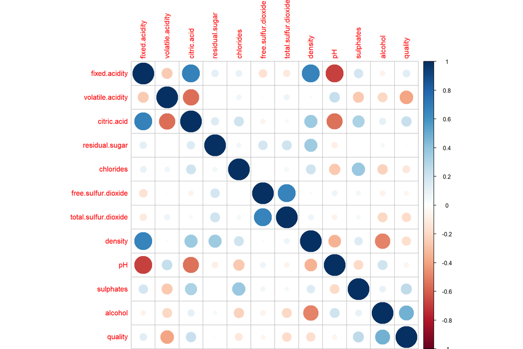

I can see my correlation, and I can predict that % of alcohol and the level of volatile acidicty affect the most among them.

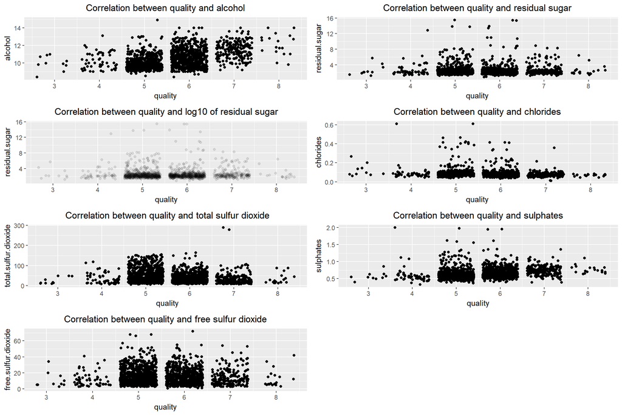

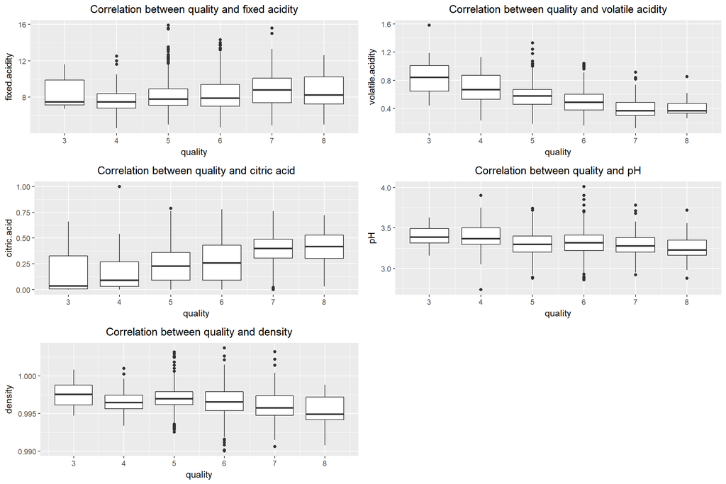

# Bivariate Analysis

### What was the strongest relationship you found?

The quality of wine has the strongest relationship with the level of volatile acidity and the level of alcohol. It also has some relationship with the amount of sulphates and the level of citric acid.

# Multivariate Plots Section

From the data above, I can tentatively conclude that % of alcohol, the amount of sulphates, and level of citric acid and volatile acidity are the biggest factors on the quality of wines. The following plots will prove if they are true or not.

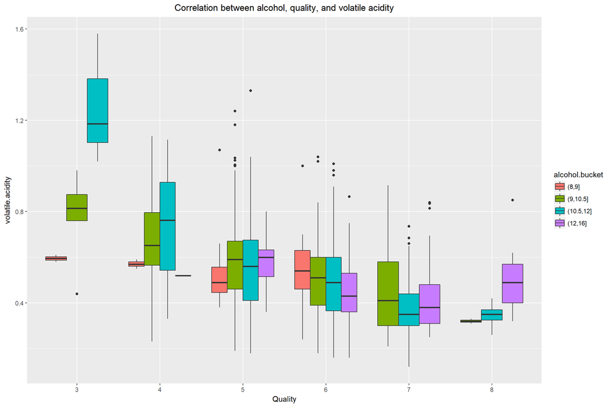

First I cut alcohol to make it a factor, then create a boxplot that accepts three variables: alcohol, quality, volatile acidity, which are two most important factors according to correlation. I can see that higher quality of wines have higher alcohol (which is purple) and lower volatile acidity.

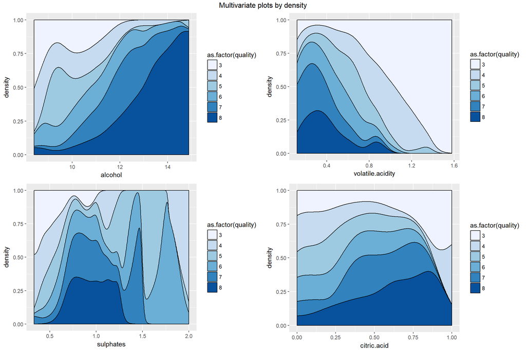

Plot above is a summerise of 4 top correlation variables (alcohol, volatile acidity, sulhpates, and citric acid.) Now everything is clear.

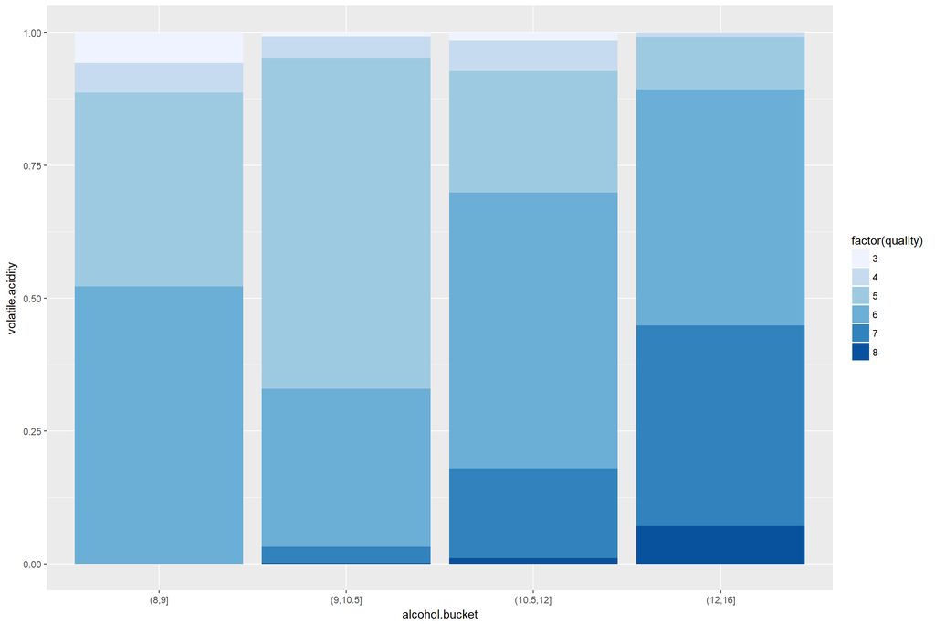

# Multivariate Analysis

### Talk about some of the relationships you observed in this part of the investigation. Were there features that strengthened each other in terms of looking at your feature(s) of interest?

With the analysis above, I can conclude that, in addition to the proportion of each variables, at which point the quality of wines peaks.

### Were there any interesting or surprising interactions between features?

I was surprised that even if volatile acidity has the strongest negative proportional with the quality of wines, still there needs some (approximately 0.2 g/dm^3)

### OPTIONAL: Did you create any models with your dataset? Discuss the strengths and limitations of your model.

I didn’t create any models.

# Final Plots and Summary

### Plot One

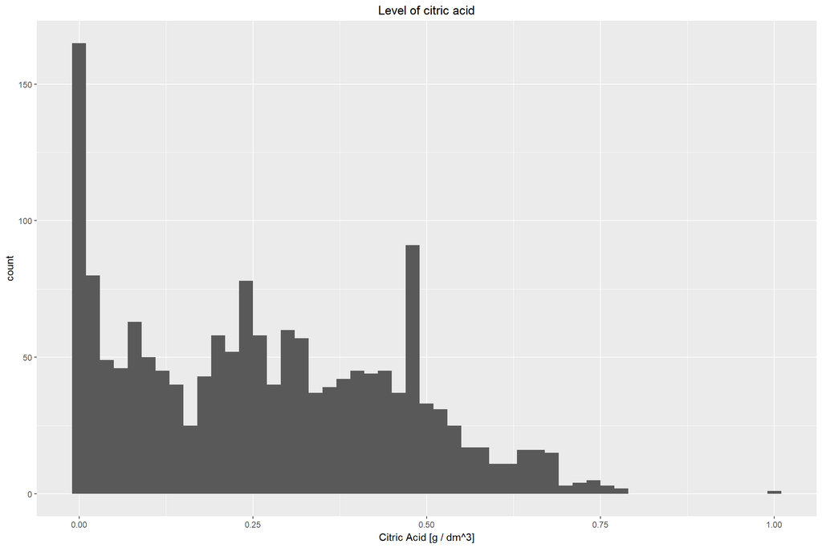

### Description One

There are so many wines that have 0 citric acid. It is still curious if that’s because they have no data or actually there are wines that have no citric acid at all.

### Plot Two

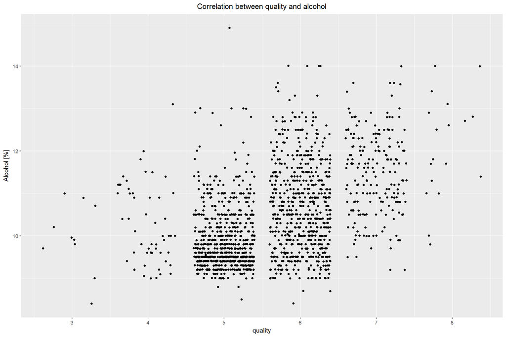

### Description Two

It is interesting how alcohol affects the quality of wines. The percentage of alcohol is normally, unless it is abnormally high or low, not considered as one of factors that decides the quality of wines, but actually it is the most important factor among all other chemical components.

### Plot Three

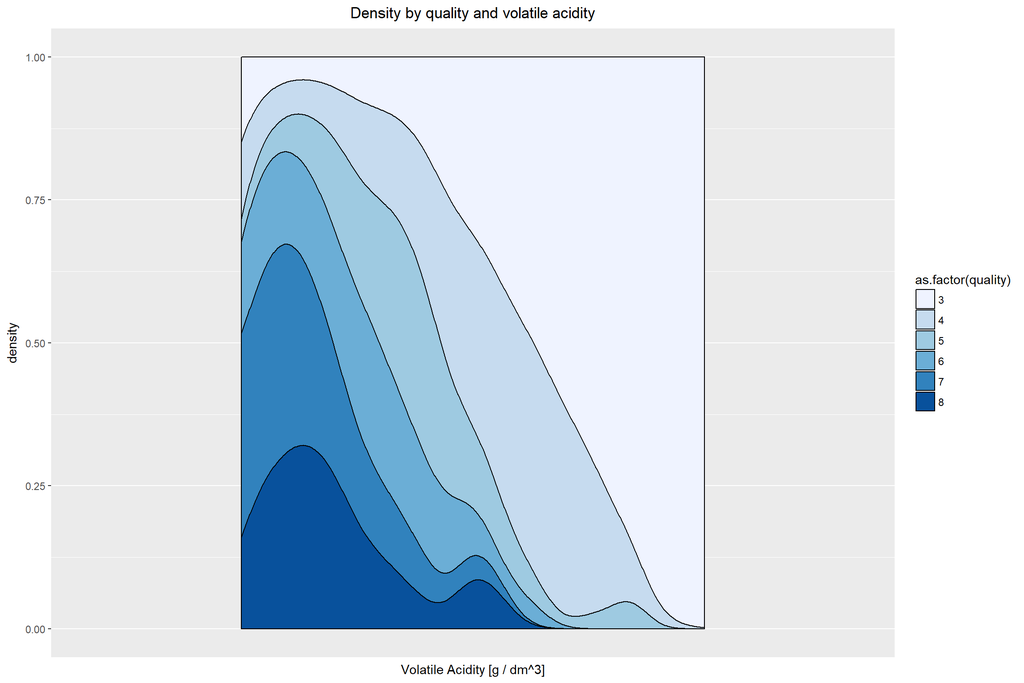

### Description Three

As described on multivariate plots, it is surprising that even though volatile acidity is a chemical component that can lead to an unpleasant, vinegar taste, it is still necessary for the good quality of wines.  
——

# Reflection

This report explores a dataset containg acid and ingredients, % of alcohol, and the quality of wine with 1599 rows. I explored the dataset in order to find out which factors affect positively or negatively, and which one does the most and the least.

I had struggle when I try to find more than 3 relationships, because all the variables seem independent. However yet I was successfully found what decides the quality of wines and how much it actually affects.

After exploring dataset, the correlation between the quality of wines and other factors are clear, being able to predict what the quality of a certain wine will be by looking up those factors. The most interesting fact is, if the percent of alcohol of a wine is lower than average, it is very likely rated as low quality.

It was able to get a good result from this dataset by using R, but I could get the better results if I had more data, as it had only 1599 rows. I would be able to get the better result if there was a variable about what the wine was made of, such as the type and origin of grapes and the county of manufacture.